# Customer Lifetime Value Analysis Report

# TEAM 3 : Pi-oneers

## The Fellowship of the errors.

## Group Members

- Marion - 20BDA04
- Bismi - 20BDA07
- Lakshmi - 20BDA09
- Glennis - 20BDA24
- Gargi - 20BDA55
- Ajay - 20BDA64

# INTRODUCTION

[output not shown]

## Dataset Description

```
In the dataset there are 9134 observations and 24 variables. The dependent variable is  Customer.Lifetime.Value. The independent variables are:
```

- Customer (Unique ID assigned to customers).
- State (State to which customers belong).
  - Arizona, Nevada, Oregon, California, Washington
- Customer Lifetime Value (Net profit generated by customers for the firm).
- Response(Positive or negative response with regards to purchase of policy plans).
  - No, Yes
- Coverage (Policy coverage chosen by the customers).
  - Basic, Extended, Premium
- Education (Education received by the customers).
  - Bachelor, College, Doctor, HighSchool or Below, Master
- Effective To Date (Maturity date of insurance policy plan).
- EmploymentStatus (Customers’ current employment status).
  - Employed, Unemployed, Disabled, Retired, Medical Leave
- Gender (Gender of customers).
  - F(Female), M(Male)
- Income (Income level of cusomers).
- Location Code (Type of residential area of cusomers).
  - Rural, Suburban, Urban
- Marital Status (Relationship status).
  - Divorced, Married, Single
- Monthly Premium Auto (Monthly premium paid for the policy).
- Months Since Last Claim (Number of months that passed since the last claim made by the customer).
- Months Since Policy Inception (Number of months since the activation of policy plan).
- Number of Open Complaints (Number of unsolved complaints made by the customer).
- Number of Policies (Total number of policies purchased).
- Policy Type (Type of policy under the main categories).
  - Corporate Auto, Personel Auto, Special Auto
- Policy (Category of policy plan adopted by the customer).
  - personal L1, personel L2, personel L3, corporate L1, corporate L2, corporate L3, special L1, special L2, special L3
- Renew Offer Type (Class of renewal offer accepted by the customer).
  - offer 1, offer 2, offer 3, offer 4
- Sales Channel (Channel via sales with a particular customer occurred).
  - Agent, Branch, Call centre, Web
- Total Claim Amount(Total amount that can be claimed by the customer on/before policy maturity).
- Vehicle Class (Class to which the insured vehicle belongs).
  - Four-Door-Car, Luxury car, Luxury SUV, Sports Car, SUV, Two-Door-Car
- Vehicle Size (Size of the customers’ insured vehicle).

## Objective - Predict Customer Lifetime Value of a vehicle insurance company.

### Installing packages required

```r
#1. Hmisc
library(Hmisc)
```

```r
#2. ggplot2
library(ggplot2)
#3.tidyverse
library(tidyverse)
#4.MASS
library(MASS)  # for stepAIC
#5.psych
library(psych)  # for describe
#6.modelr
library(modelr) # for r squared
#7.randomForest
library(randomForest)  #for random forest
#8.klaR
library(klaR)
#9.dplyr
library(dplyr)
#10.caret
library(caret)
#11.car
library(car)
```

### Loading data

```r
#Setting path
setwd('C:/Users/ajiva/Desktop/Akhileswar')


#Importing data
data <- read.csv('CLVdata.csv',
                 header=TRUE)

head(data)
```

```
##   Customer      State Customer.Lifetime.Value Response Coverage Education
## 1  BU79786 Washington                2763.519       No    Basic  Bachelor
## 2  QZ44356    Arizona                6979.536       No Extended  Bachelor
## 3  AI49188     Nevada               12887.432       No  Premium  Bachelor
## 4  WW63253 California                7645.862       No    Basic  Bachelor
## 5  HB64268 Washington                2813.693       No    Basic  Bachelor
## 6  OC83172     Oregon                8256.298      Yes    Basic  Bachelor
##   Effective.To.Date EmploymentStatus Gender Income Location.Code Marital.Status
## 1           2/24/11         Employed      F  56274      Suburban        Married
## 2           1/31/11       Unemployed      F      0      Suburban         Single
## 3           2/19/11         Employed      F  48767      Suburban        Married
## 4           1/20/11       Unemployed      M      0      Suburban        Married
## 5            2/3/11         Employed      M  43836         Rural         Single
## 6           1/25/11         Employed      F  62902         Rural        Married
##   Monthly.Premium.Auto Months.Since.Last.Claim Months.Since.Policy.Inception
```

[output cut: 20 more lines]

```r
#Viewing Data
View(data)

#Checking for missing values
colSums(is.na(data))
```

```
##                      Customer                         State
##                             0                             0
##       Customer.Lifetime.Value                      Response
##                             0                             0
##                      Coverage                     Education
##                             0                             0
##             Effective.To.Date              EmploymentStatus
##                             0                             0
##                        Gender                        Income
##                             0                             0
##                 Location.Code                Marital.Status
##                             0                             0
##          Monthly.Premium.Auto       Months.Since.Last.Claim
##                             0                             0
## Months.Since.Policy.Inception     Number.of.Open.Complaints
##                             0                             0
##            Number.of.Policies                   Policy.Type
##                             0                             0
##                        Policy              Renew.Offer.Type
##                             0                             0
##                 Sales.Channel            Total.Claim.Amount
##                             0                             0
##                 Vehicle.Class                  Vehicle.Size
##                             0                             0
```

```r
#Summary of data
str(data)
```

```
## 'data.frame':    9134 obs. of  24 variables:
##  $ Customer                     : chr  "BU79786" "QZ44356" "AI49188" "WW63253" ...
##  $ State                        : chr  "Washington" "Arizona" "Nevada" "California" ...
##  $ Customer.Lifetime.Value      : num  2764 6980 12887 7646 2814 ...
##  $ Response                     : chr  "No" "No" "No" "No" ...
##  $ Coverage                     : chr  "Basic" "Extended" "Premium" "Basic" ...
##  $ Education                    : chr  "Bachelor" "Bachelor" "Bachelor" "Bachelor" ...
##  $ Effective.To.Date            : chr  "2/24/11" "1/31/11" "2/19/11" "1/20/11" ...
##  $ EmploymentStatus             : chr  "Employed" "Unemployed" "Employed" "Unemployed" ...
##  $ Gender                       : chr  "F" "F" "F" "M" ...
##  $ Income                       : int  56274 0 48767 0 43836 62902 55350 0 14072 28812 ...
##  $ Location.Code                : chr  "Suburban" "Suburban" "Suburban" "Suburban" ...
##  $ Marital.Status               : chr  "Married" "Single" "Married" "Married" ...
##  $ Monthly.Premium.Auto         : int  69 94 108 106 73 69 67 101 71 93 ...
##  $ Months.Since.Last.Claim      : int  32 13 18 18 12 14 0 0 13 17 ...
##  $ Months.Since.Policy.Inception: int  5 42 38 65 44 94 13 68 3 7 ...
##  $ Number.of.Open.Complaints    : int  0 0 0 0 0 0 0 0 0 0 ...
##  $ Number.of.Policies           : int  1 8 2 7 1 2 9 4 2 8 ...
##  $ Policy.Type                  : chr  "Corporate Auto" "Personal Auto" "Personal Auto" "Corporate Auto" ...
##  $ Policy                       : chr  "Corporate L3" "Personal L3" "Personal L3" "Corporate L2" ...
##  $ Renew.Offer.Type             : chr  "Offer1" "Offer3" "Offer1" "Offer1" ...
##  $ Sales.Channel                : chr  "Agent" "Agent" "Agent" "Call Center" ...
##  $ Total.Claim.Amount           : num  385 1131 566 530 138 ...
##  $ Vehicle.Class                : chr  "Two-Door Car" "Four-Door Car" "Two-Door Car" "SUV" ...
##  $ Vehicle.Size                 : chr  "Medsize" "Medsize" "Medsize" "Medsize" ...
```

```r
summary(data)
```

```
##    Customer            State           Customer.Lifetime.Value
##  Length:9134        Length:9134        Min.   : 1898
##  Class :character   Class :character   1st Qu.: 3994
##  Mode  :character   Mode  :character   Median : 5780
##                                        Mean   : 8005
##                                        3rd Qu.: 8962
##                                        Max.   :83325
##    Response           Coverage          Education         Effective.To.Date
##  Length:9134        Length:9134        Length:9134        Length:9134
##  Class :character   Class :character   Class :character   Class :character
##  Mode  :character   Mode  :character   Mode  :character   Mode  :character
##
##
##
##  EmploymentStatus      Gender              Income      Location.Code
##  Length:9134        Length:9134        Min.   :    0   Length:9134
##  Class :character   Class :character   1st Qu.:    0   Class :character
##  Mode  :character   Mode  :character   Median :33890   Mode  :character
##                                        Mean   :37657
##                                        3rd Qu.:62320
##                                        Max.   :99981
##  Marital.Status     Monthly.Premium.Auto Months.Since.Last.Claim
##  Length:9134        Min.   : 61.00       Min.   : 0.0
##  Class :character   1st Qu.: 68.00       1st Qu.: 6.0
##  Mode  :character   Median : 83.00       Median :14.0
##                     Mean   : 93.22       Mean   :15.1
##                     3rd Qu.:109.00       3rd Qu.:23.0
##                     Max.   :298.00       Max.   :35.0
##  Months.Since.Policy.Inception Number.of.Open.Complaints Number.of.Policies
##  Min.   : 0.00                 Min.   :0.0000            Min.   :1.000
##  1st Qu.:24.00                 1st Qu.:0.0000            1st Qu.:1.000
##  Median :48.00                 Median :0.0000            Median :2.000
##  Mean   :48.06                 Mean   :0.3844            Mean   :2.966
##  3rd Qu.:71.00                 3rd Qu.:0.0000            3rd Qu.:4.000
##  Max.   :99.00                 Max.   :5.0000            Max.   :9.000
##  Policy.Type           Policy          Renew.Offer.Type   Sales.Channel
##  Length:9134        Length:9134        Length:9134        Length:9134
##  Class :character   Class :character   Class :character   Class :character
##  Mode  :character   Mode  :character   Mode  :character   Mode  :character
##
##
##
##  Total.Claim.Amount Vehicle.Class      Vehicle.Size
##  Min.   :   0.099   Length:9134        Length:9134
##  1st Qu.: 272.258   Class :character   Class :character
##  Median : 383.945   Mode  :character   Mode  :character
##  Mean   : 434.089
##  3rd Qu.: 547.515
##  Max.   :2893.240
```

## EDA

Here we perform summary statistics and graphical representations on insurance data, to get better understanding and insights.

Decriptive Analysis of Customer Lifetime Value(CLV)

```r
describe(data$Customer.Lifetime.Value)
```

```
##    vars    n    mean      sd  median trimmed    mad     min      max    range
## X1    1 9134 8004.94 6870.97 5780.18 6631.05 3658.9 1898.01 83325.38 81427.37
##    skew kurtosis    se
## X1 3.03    13.81 71.89
```

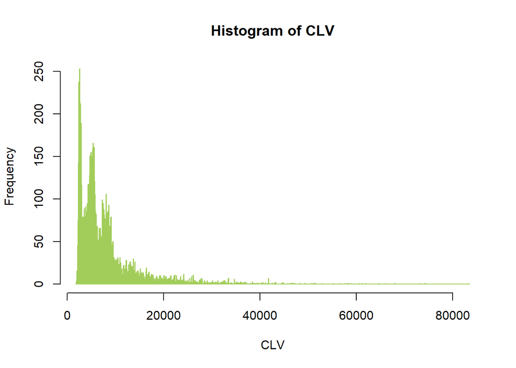

```
The distribution is positively skewed. Most values lie towards left. Maximum CLV is 83325.381. Minimum CLV is 1898.008. Mean value is 8005, Median is 5780.
From this we can say that company makes a lot of business with few high range customers. A loss of few of these customers would have a similar impact to that of a loss of many of low paying customers.
```

```r
hist(data$Customer.Lifetime.Value,
     breaks = (max(data$Customer.Lifetime.Value) - min(data$Customer.Lifetime.Value))/100,
     main = "Histogram of CLV",
     xlab = "CLV",
     border = "darkolivegreen3")
```

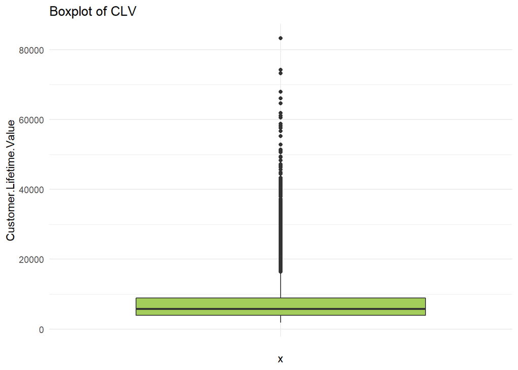

```r
ggplot(data=data) +
  aes(x = "", y = Customer.Lifetime.Value) +
  geom_boxplot(fill = "darkolivegreen3") +
  theme_minimal()+
  labs(title="Boxplot of CLV")
```

```r
outlier_percent <- function(x){
  length(which(x >  mean(x) + 3 * sd(x) | x < mean(x) - 3 * sd(x))  ) / length(x)
}
outlier_percent(data$Customer.Lifetime.Value)
```

```
## [1] 0.0231005
```

```
Observed 2.3% of outliers in CLV column. There are two ways to deal with it. One is log transformation and the other is clipping.
```

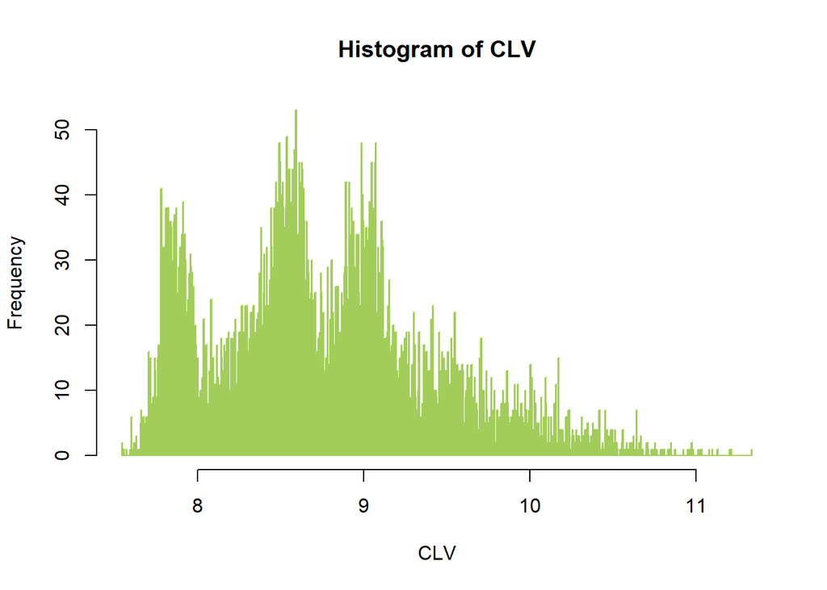

```
Taking natural logarithm of values, can eliminate the effect of outliers upto certain extent as able to get less skewed distribution.
```

```r
options(repr.plot.width=5, repr.plot.height=4)
hist(log1p(data$Customer.Lifetime.Value),
     breaks = (max(data$Customer.Lifetime.Value) - min(data$Customer.Lifetime.Value))/100,
     main = "Histogram of CLV",
     xlab = "CLV",
     border = "darkolivegreen3")
```

#### EDA of numerical variables.

##### Monthly Premium

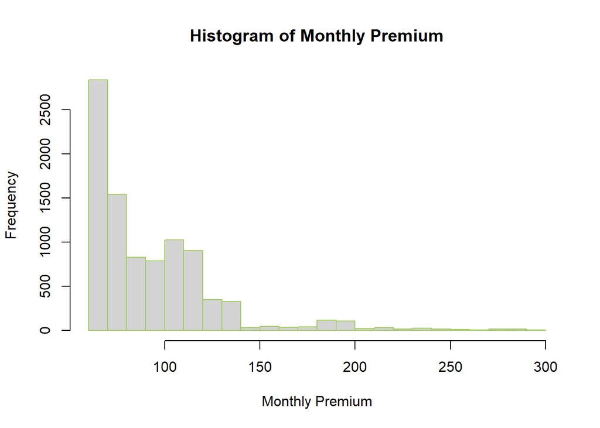

```
  The distribution is positively skewed and most values and concentrated on the left side.
  Maximum MPA is 298 and Minimum is 61.
```

```r
options(repr.plot.width=5, repr.plot.height=5)
hist(data$Monthly.Premium.Auto,
     breaks = (max(data$Monthly.Premium.Auto) - min(data$Monthly.Premium.Auto))/10,
     main = "Histogram of Monthly Premium",
     xlab = "Monthly Premium",
     border = "darkolivegreen3")
```

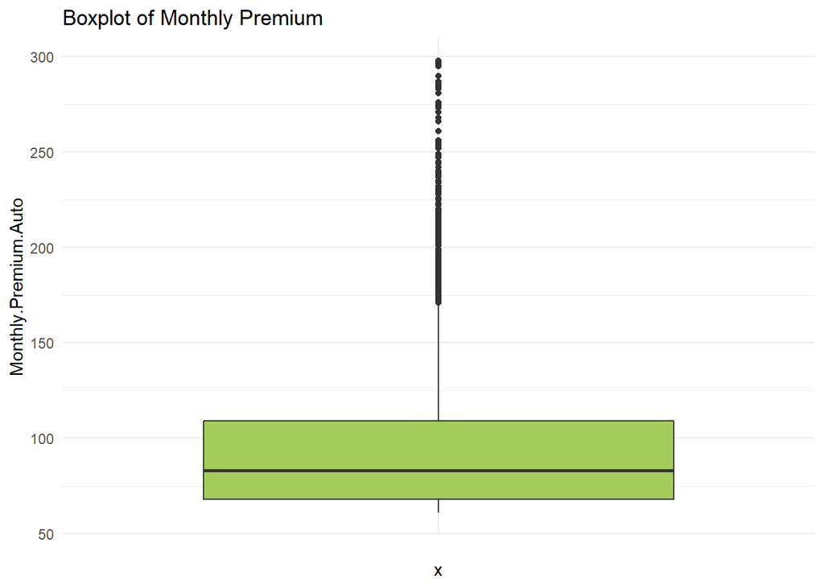

```r
ggplot(data=data) +
  aes(x = "", y = Monthly.Premium.Auto) +
  geom_boxplot(fill = "darkolivegreen3") +
  theme_minimal()+
  labs(title="Boxplot of Monthly Premium")
```

```r
outlier_percent(data$Monthly.Premium.Auto)
```

```
## [1] 0.02189621
```

```
2.18 % of outliers present.
```

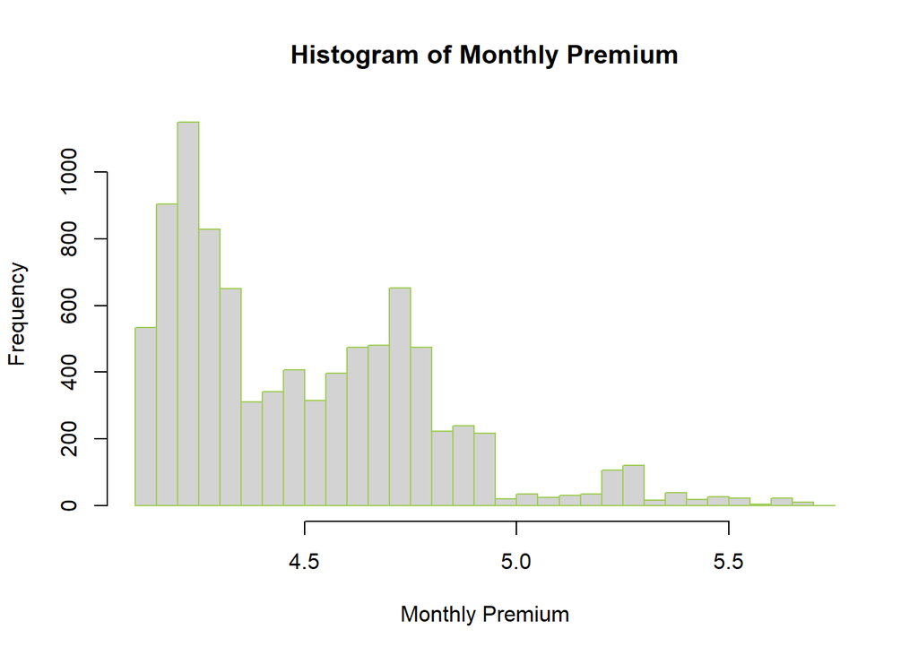

```r
options(repr.plot.width=5, repr.plot.height=4)
hist(log1p(data$Monthly.Premium.Auto),
     breaks = (max(data$Monthly.Premium.Auto) - min(data$Monthly.Premium.Auto))/10,
     main = "Histogram of Monthly Premium",
     xlab = "Monthly Premium",
     border = "darkolivegreen3")
```

##### Total Claim Amount

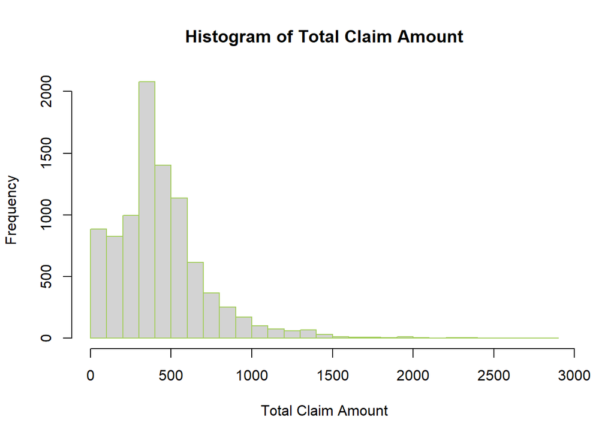

```
 The distribution is positively skewed and most values and concentrated on the left side.
 Maximum TCA is 2893.24 and minimum is 0.0990.
```

```r
options(repr.plot.width=5, repr.plot.height=5)
hist(data$Total.Claim.Amount,
     breaks = (max(data$Total.Claim.Amount) - min(data$Total.Claim.Amount))/100,
     main = "Histogram of Total Claim Amount",
     xlab = "Total Claim Amount",
     border = "darkolivegreen3")
```

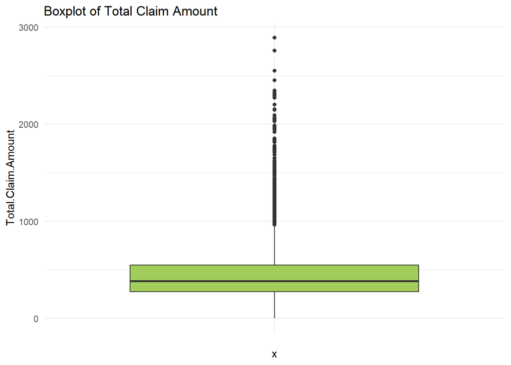

```r
ggplot(data=data) +
  aes(x = "", y = Total.Claim.Amount) +
  geom_boxplot(fill = "darkolivegreen3") +
  theme_minimal()+
  labs(title="Boxplot of Total Claim Amount")
```

```r
outlier_percent(data$Total.Claim.Amount)
```

```
## [1] 0.01729801
```

```
1.7% of outliers present.
```

##### Income

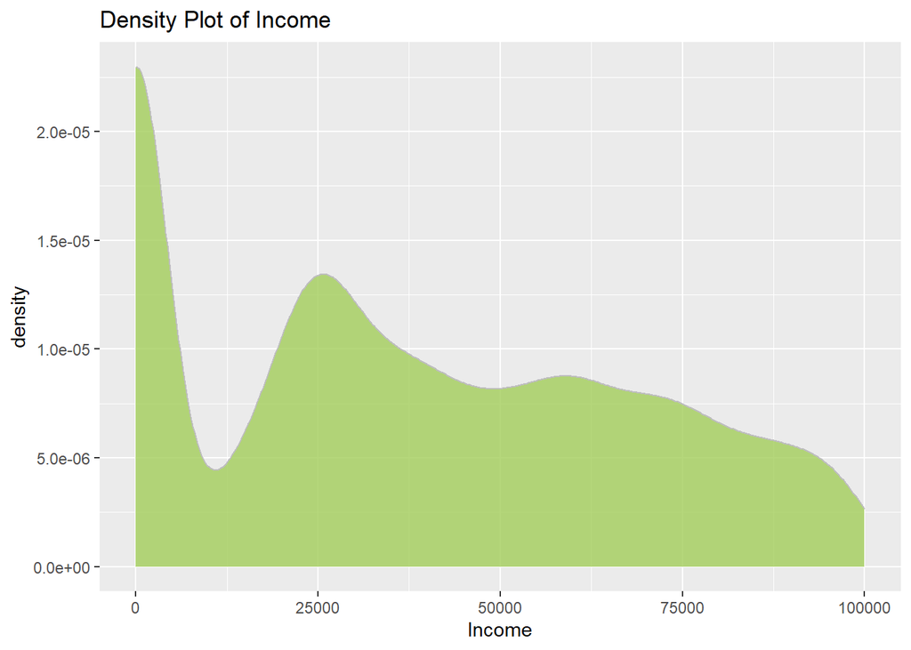

```
Here we see a right skewed distribution as expected for an income distribution. But we see an unusually high amount of zero income as a high number of the customers in this population are unemployed (Students).
```

```r
options(repr.plot.width=5, repr.plot.height=4)
data %>%
  ggplot( aes(x=Income)) +
  geom_density(fill="darkolivegreen3", color="grey", alpha=0.8)+
  labs(title="Density Plot of Income")
```

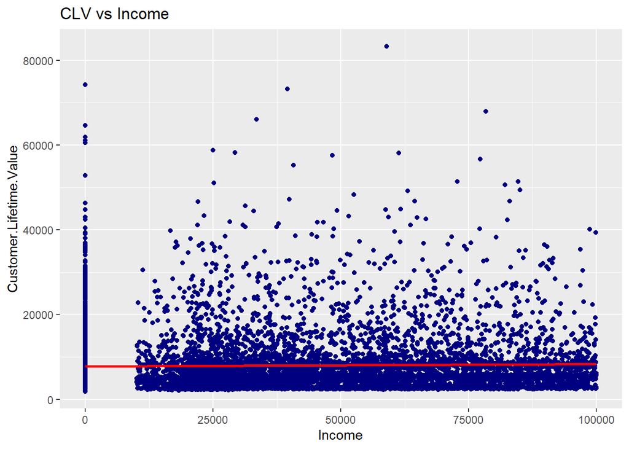

```
Valuable customers are not decided by their income. The red line here is a regression line, indicating regression between customer lifetime value (dependent) and income (independent).
```

```r
CLVIncome <- ggplot(data, aes(x=Income, y=Customer.Lifetime.Value,)) +
  geom_point( color="navyblue") +
  geom_smooth(method=lm , color="red", fill="blue", se=TRUE)+
  labs(title = "CLV vs Income")
CLVIncome
```

#### EDA for Categorical Variables

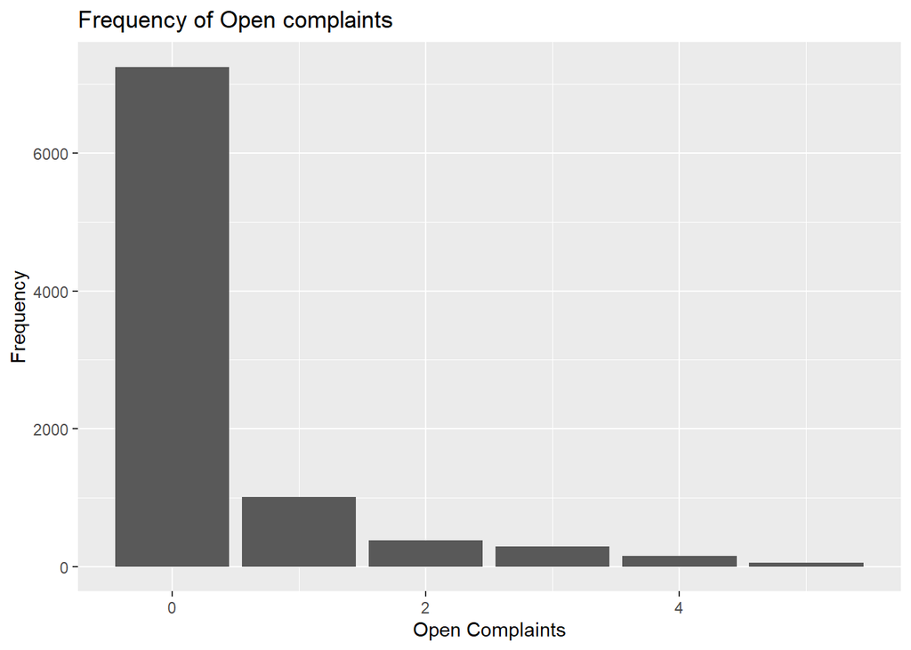

```
    Most customers have zero complaints.
```

```r
options(repr.plot.width=7, repr.plot.height=4)
GraphNumComplaints <- ggplot(data, aes(x=Number.of.Open.Complaints)) +
geom_bar(stat = "count", position = "dodge")+
  labs(title="Frequency of Open complaints",
       x="Open Complaints",
       y="Frequency")

GraphNumComplaints
```

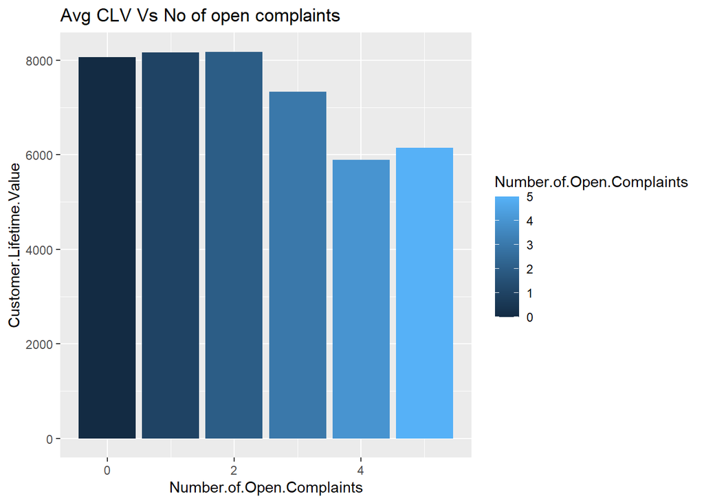

```
Customers who complaints more are observed to be less valuable.
```

```r
options(repr.plot.width=7, repr.plot.height=4)
GraphNumComplaints <- ggplot(data, aes(x=Number.of.Open.Complaints, y=Customer.Lifetime.Value,
fill = Number.of.Open.Complaints)) +
geom_bar(stat = "summary",fun="mean")+
  labs(title="Avg CLV Vs No of open complaints")

GraphNumComplaints
```

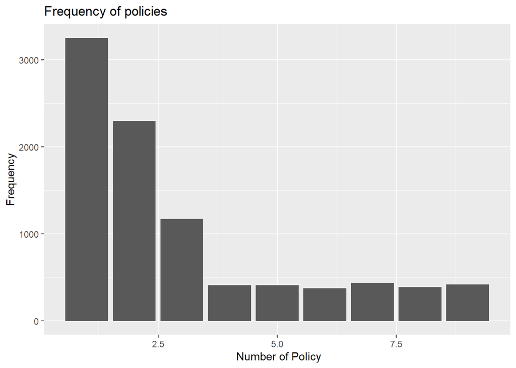

```r
options(repr.plot.width=7, repr.plot.height=4)
GraphNumPols <- ggplot(data, aes(x=Number.of.Policies)) +
geom_bar(stat = "count",position="dodge")+
  labs(title="Frequency of policies",
       x=" Number of Policy",
       y="Frequency")

GraphNumPols
```

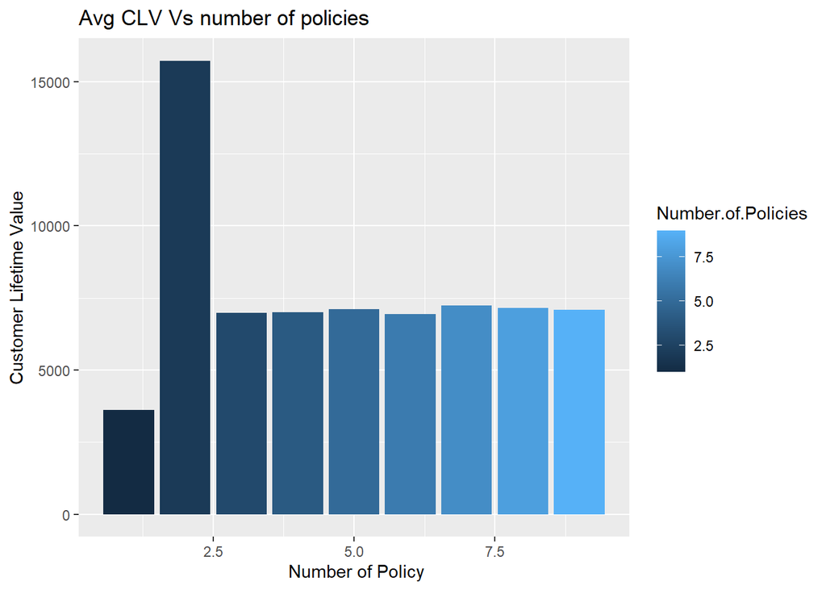

```
 The customers holding two policies are expected to be more valuable than customers holding higher than two. Least valuable customers are those with only one policy.
```

```r
options(repr.plot.width=7, repr.plot.height=4)
GraphNumPols <- ggplot(data, aes(x=Number.of.Policies, y=Customer.Lifetime.Value, fill = Number.of.Policies)) +
geom_bar(stat = "summary",fun="mean")+
  labs(title="Avg CLV Vs number of policies",
       x=" Number of Policy",
       y="Customer Lifetime Value")


GraphNumPols
```

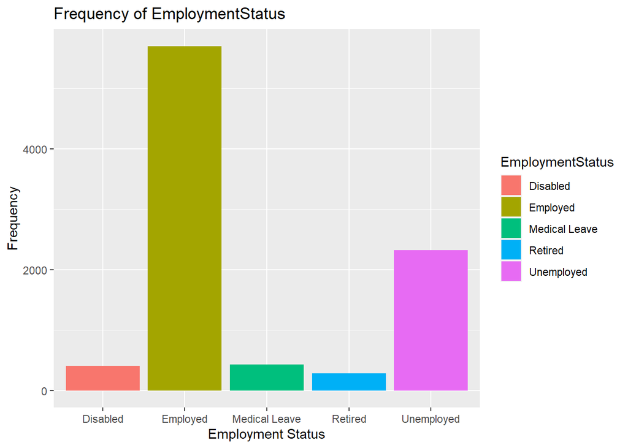

```r
options(repr.plot.width=7, repr.plot.height=4)
GraphEmpStatus <- ggplot(data, aes(x=EmploymentStatus, fill = EmploymentStatus)) +
geom_bar(stat = "count")+
  labs(title="Frequency of EmploymentStatus",
       x="Employment Status",
       y="Frequency")

GraphEmpStatus
```

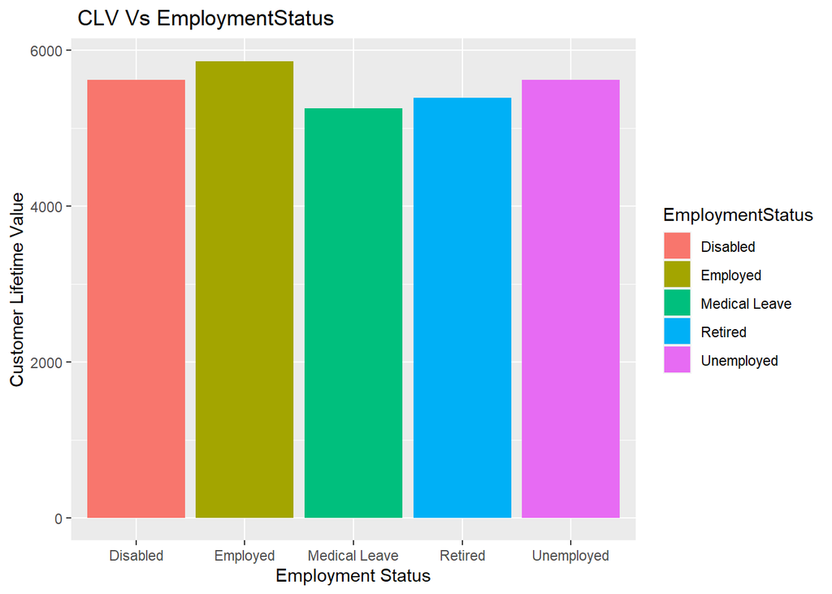

```
Average CLV of customers more or less similar irrespective of their employment status.           Employment status of the customers doesn't effect their value.
```

```r
options(repr.plot.width=7, repr.plot.height=4)
GraphEmpStatus <- ggplot(data, aes(x=EmploymentStatus, y=Customer.Lifetime.Value, fill = EmploymentStatus)) +
geom_bar(stat = "summary",fun="median")+
 labs(title=" CLV Vs EmploymentStatus",
       x="Employment Status",
       y="Customer Lifetime Value")

GraphEmpStatus
```

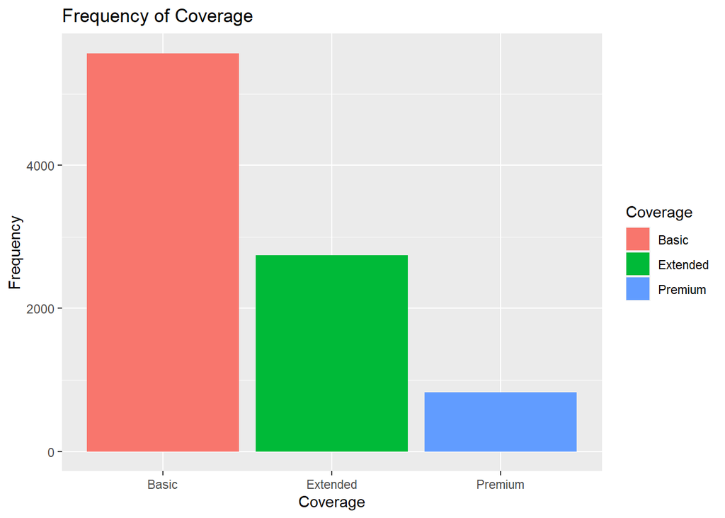

```r
options(repr.plot.width=7, repr.plot.height=4)
GraphCoverage <- ggplot(data, aes(x=Coverage,  fill = Coverage)) +
geom_bar(stat = "count")+
  labs(title = "Frequency of Coverage",
       x="Coverage",
       y="Frequency")

GraphCoverage
```

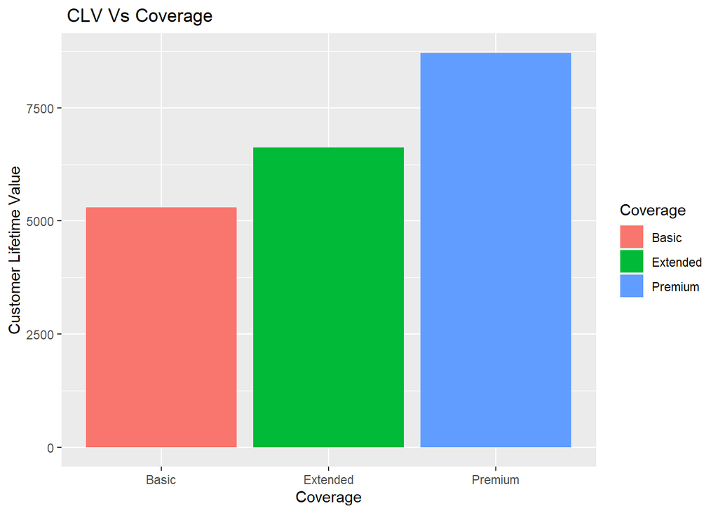

```
 Customers paying for a higher coverage are more valuable.
```

```r
options(repr.plot.width=7, repr.plot.height=4)
GraphCoverage <- ggplot(data, aes(x=Coverage, y=Customer.Lifetime.Value, fill = Coverage)) +
geom_bar(stat = "summary",fun="median")+
  labs(title = " CLV Vs Coverage",
       x="Coverage",
       y="Customer Lifetime Value")


GraphCoverage
```

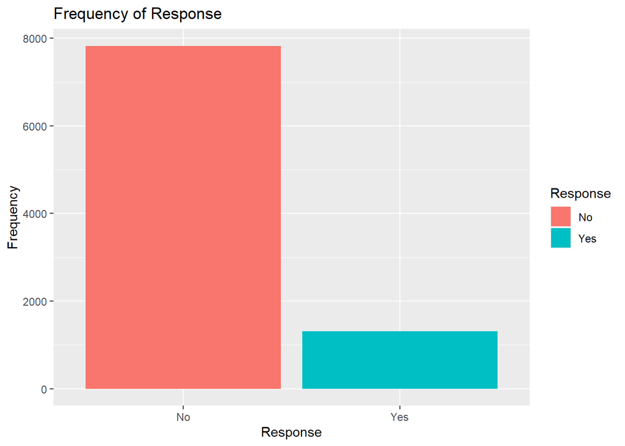

```
  Most of the customers are unhappy/unsatisfied with their purchase of the policy.
```

```r
options(repr.plot.width=7, repr.plot.height=4)
GraphResponse <- ggplot(data, aes(x=Response,  fill = Response)) +
geom_bar(stat = "count")+
  labs(title="Frequency of Response",
       x="Response",
       y="Frequency")

GraphResponse
```

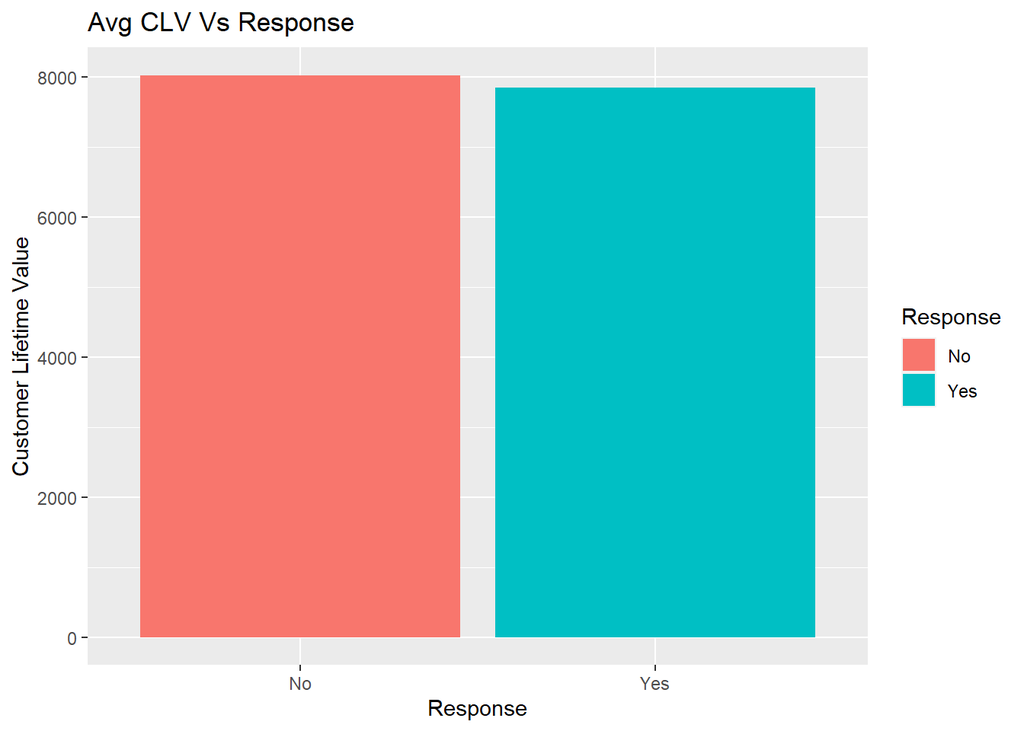

```r
options(repr.plot.width=7, repr.plot.height=4)
GraphResponse <- ggplot(data, aes(x=Response, y=Customer.Lifetime.Value, fill = Response)) +
geom_bar(stat = "summary",fun="mean")+
  labs(title="Avg CLV Vs Response",
       x="Response",
       y="Customer Lifetime Value")


GraphResponse
```

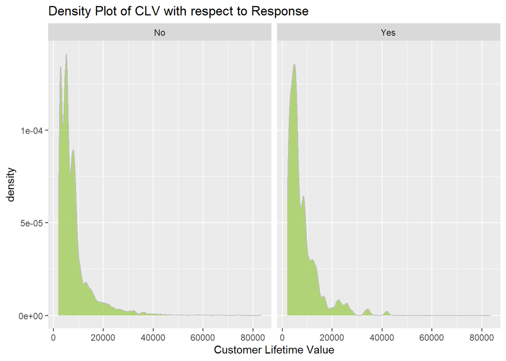

```
 Most customers had given negative response but satisfaction of a customer doesn't influence thier value. In other words, a satisfied customer on an average will spend same as that of an unsatified customer.
```

```r
options(repr.plot.width=5, repr.plot.height=4)
data %>%
  ggplot( aes(x=Customer.Lifetime.Value)) +
  facet_wrap(~Response)+
  geom_density(fill="darkolivegreen3", color="grey", alpha=0.8)+
  labs(title="Density Plot of CLV with respect to Response",
       x="Customer Lifetime Value")
```

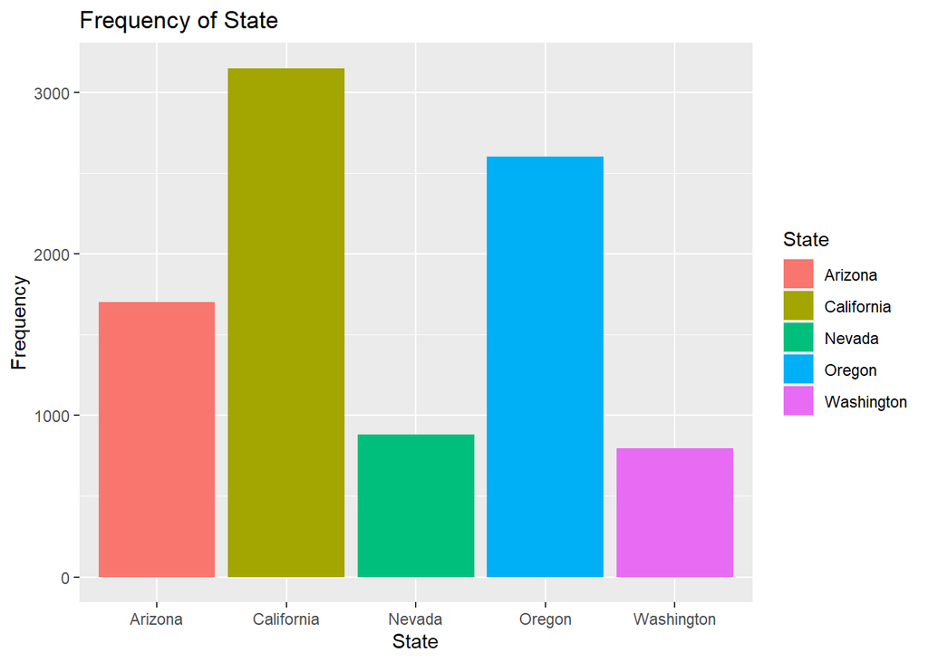

```r
options(repr.plot.width=7, repr.plot.height=4)
GraphState <- ggplot(data, aes(x=State, fill = State)) +
geom_bar(stat = "count")+
  labs(title="Frequency of State",
       y="Frequency")

GraphState
```

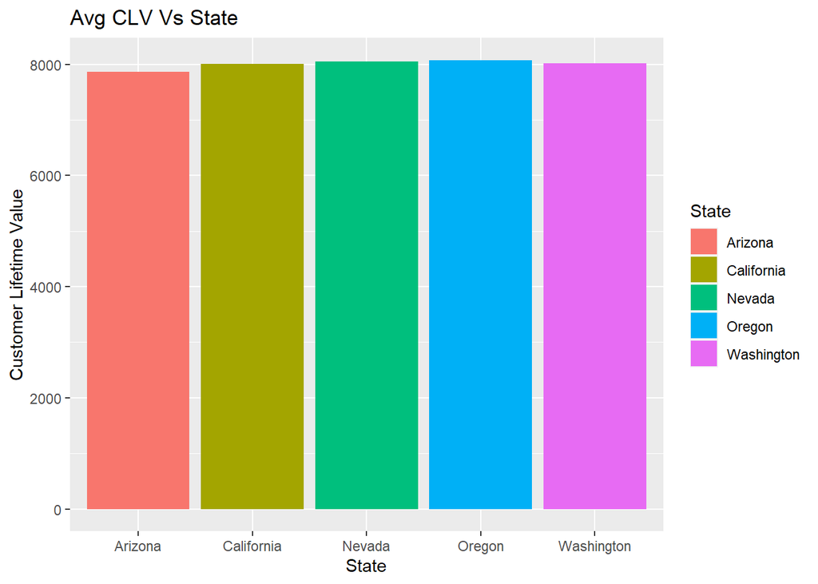

```
Most of the customers reported are from California and Oregon, but doesn't make sense if we say more valuable customers are from there.
```

```r
options(repr.plot.width=7, repr.plot.height=4)
GraphState <- ggplot(data, aes(x=State, y=Customer.Lifetime.Value, fill = State)) +
geom_bar(stat = "summary",fun="mean")+
  labs(title="Avg CLV Vs State",
       y="Customer Lifetime Value")

GraphState
```

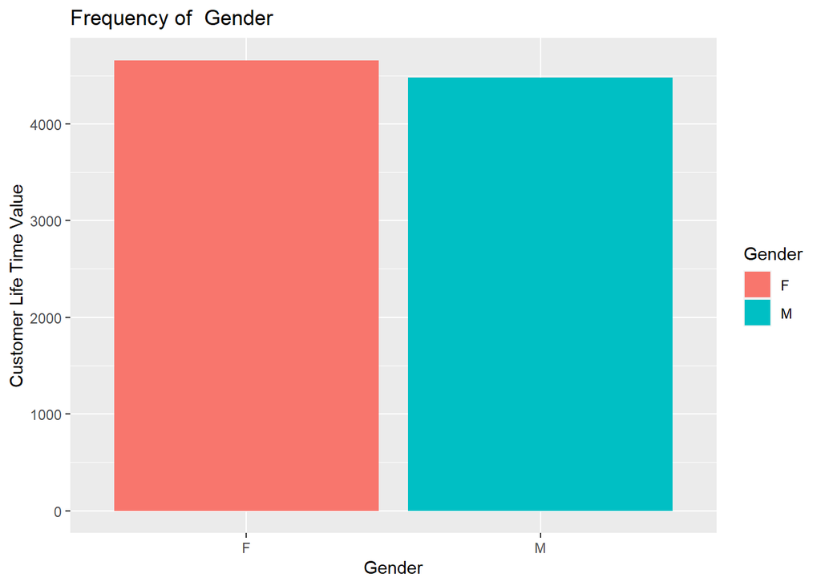

```r
GraphMF <- ggplot(data, aes(x=Gender,  fill = Gender)) +
geom_bar(stat = "count") +
labs(x="Gender",y = "Customer Life Time Value", fill="Gender") +
  ggtitle("Frequency of  Gender")

GraphMF
```

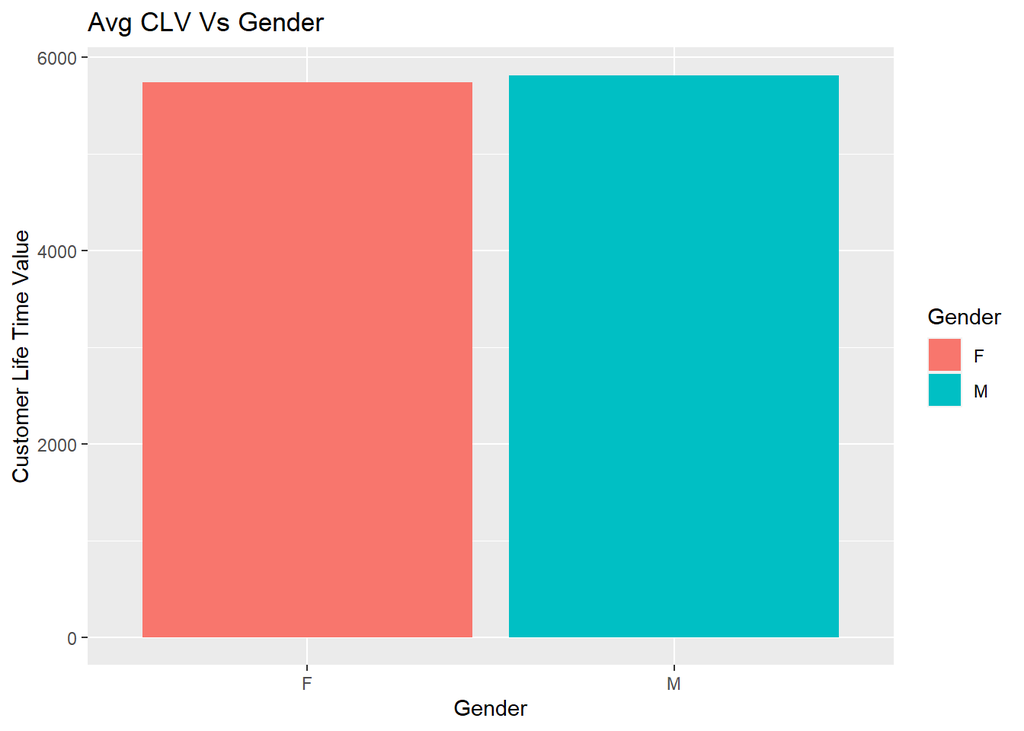

```r
GraphMF <- ggplot(data, aes(x=Gender, y=Customer.Lifetime.Value, fill = Gender)) +
geom_bar(stat = "summary",fun="median") +
labs(x="Gender",y = "Customer Life Time Value", fill="Gender") +
  ggtitle("Avg CLV Vs Gender")

GraphMF
```

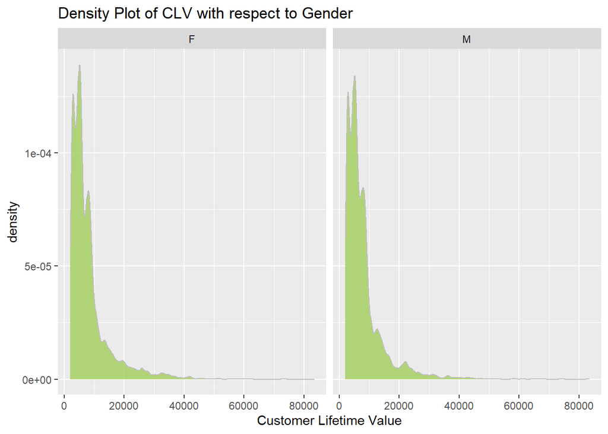

```
Both Male and Female customers are equally valuable.
```

```r
options(repr.plot.width=5, repr.plot.height=4)
data %>%
  ggplot( aes(x=Customer.Lifetime.Value)) +
  facet_wrap(~Gender)+
  geom_density(fill="darkolivegreen3", color="grey", alpha=0.8)+
  labs(title="Density Plot of CLV with respect to Gender", x="Customer Lifetime Value")
```

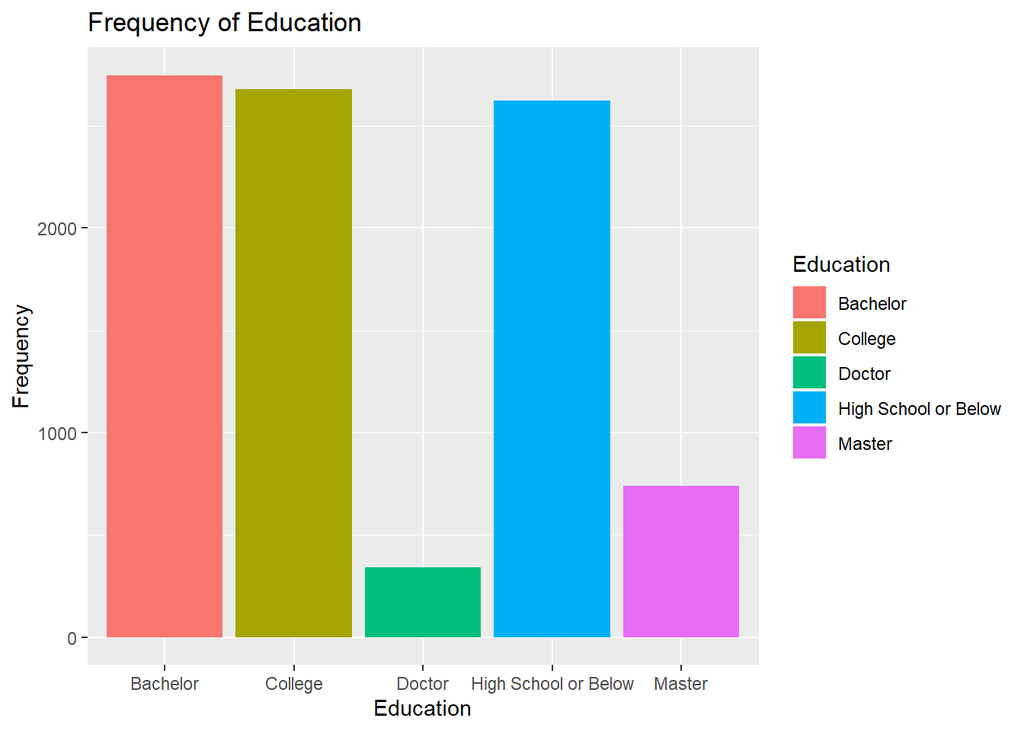

```
Most customers with education bachelor, college and highschool.
```

```r
options(repr.plot.width=7, repr.plot.height=4)
GraphEdu <- ggplot(data, aes(x=Education, fill = Education)) +
geom_bar(stat = "count")+
  labs(title="Frequency of Education",y="Frequency")

GraphEdu
```

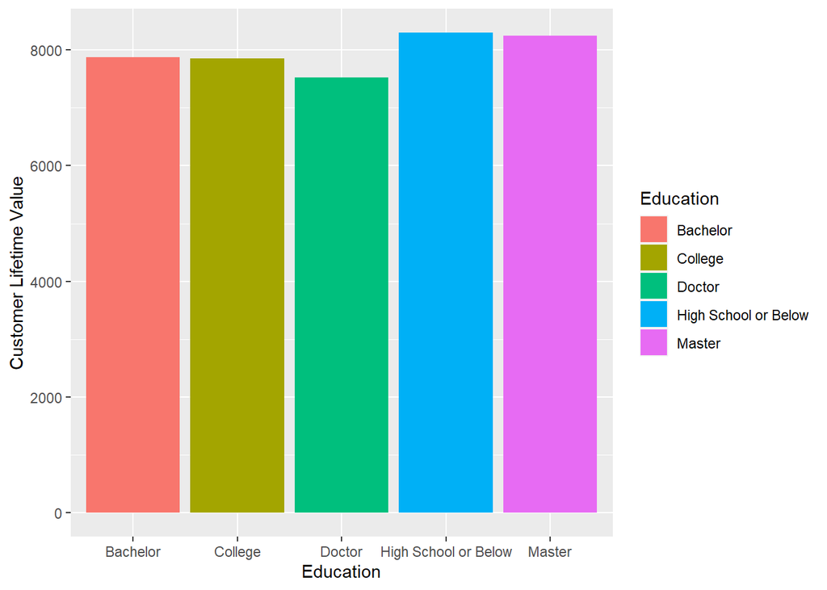

```
Education doesn't influence their CLV value.
```

```r
options(repr.plot.width=7, repr.plot.height=4)
GraphEdu <- ggplot(data, aes(x=Education, y=Customer.Lifetime.Value, fill = Education)) +
geom_bar(stat = "summary",fun="mean")+
  labs("Avg CLV Vs Education",y="Customer Lifetime Value")

GraphEdu
```

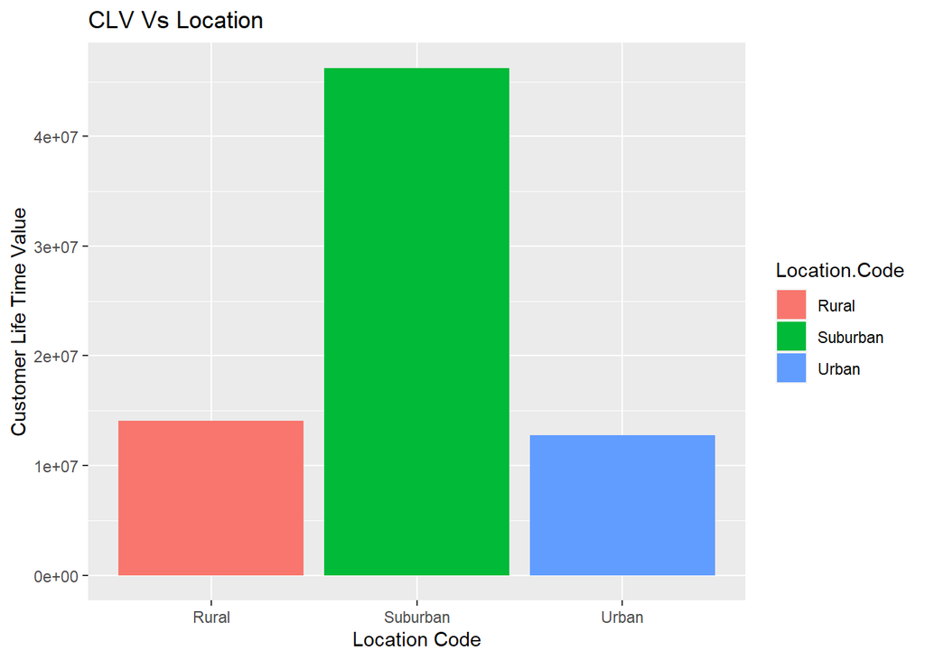

```
More customers are from suburban areas.
```

```r
options(repr.plot.width=7, repr.plot.height=4)
GraphLocCode <- ggplot(data, aes(x=Location.Code, y=Customer.Lifetime.Value, fill = Location.Code)) +
geom_bar(stat = "identity") +
labs(x="Location Code",y = "Customer Life Time Value", fill="Location.Code") +
  ggtitle("CLV Vs Location")

GraphLocCode
```

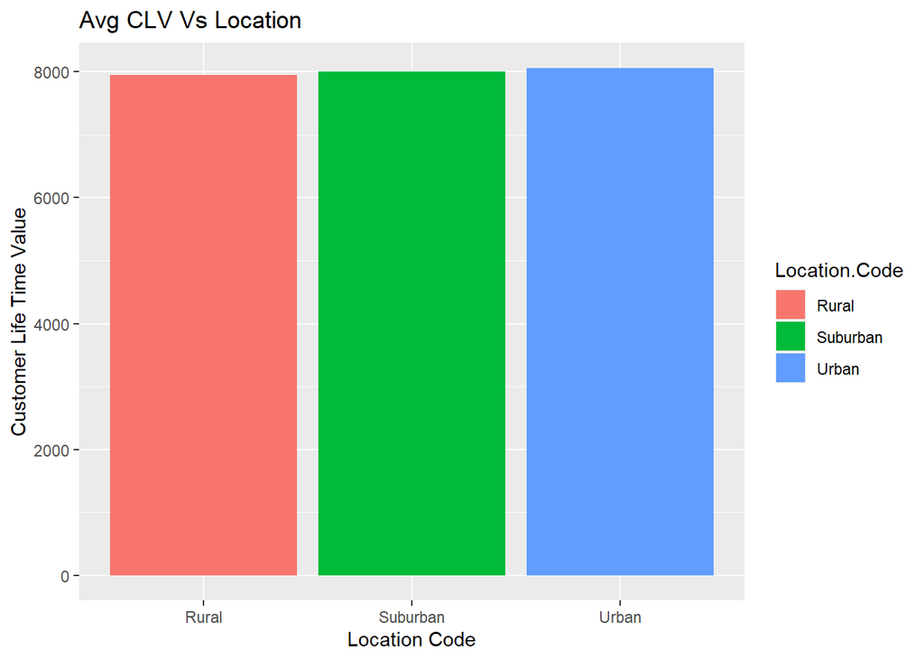

```
Location to which they belong doesn't make them more valuable.
```

```r
options(repr.plot.width=7, repr.plot.height=4)
GraphLocCode <- ggplot(data, aes(x=Location.Code, y=Customer.Lifetime.Value, fill = Location.Code)) +
geom_bar(stat = "summary",fun="mean") +
labs(x="Location Code",y = "Customer Life Time Value", fill="Location.Code") +
  ggtitle("Avg CLV Vs Location")

GraphLocCode
```

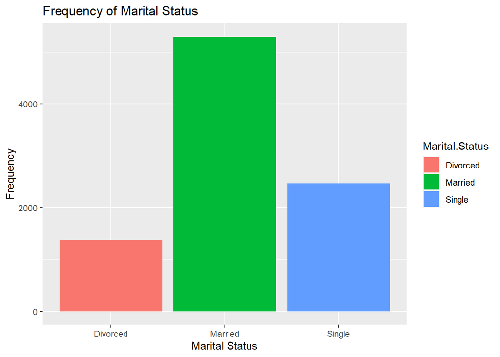

```r
options(repr.plot.width=7, repr.plot.height=4)
GraphMarStat <- ggplot(data, aes(x=Marital.Status, fill = Marital.Status)) +
geom_bar(stat = "count")+
  labs(title="Frequency of Marital Status",
       x="Marital Status",
       y="Frequency")

GraphMarStat
```

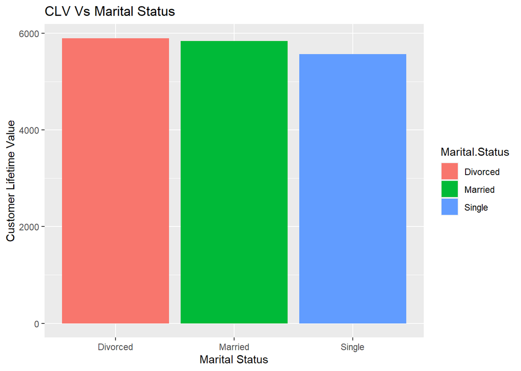

```
Most of the customers are married, but their marital status doesn't influence whether they are valuable or not.
```

```r
options(repr.plot.width=7, repr.plot.height=4)
GraphMarStat <- ggplot(data, aes(x=Marital.Status, y=Customer.Lifetime.Value, fill = Marital.Status)) +
geom_bar(stat = "summary",fun="median")+
  labs(title="CLV Vs Marital Status",x="Marital Status",
       y="Customer Lifetime Value")

GraphMarStat
```